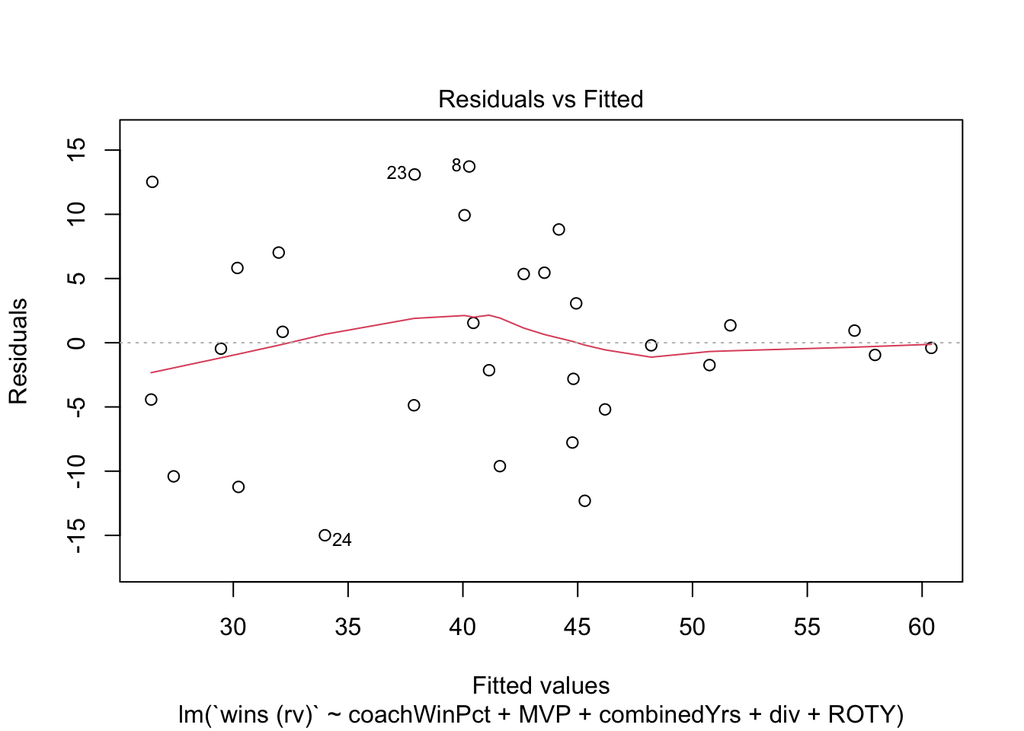

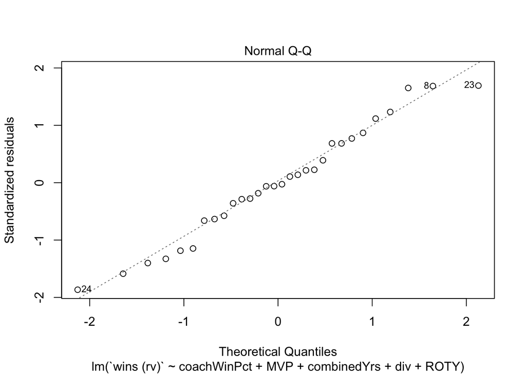

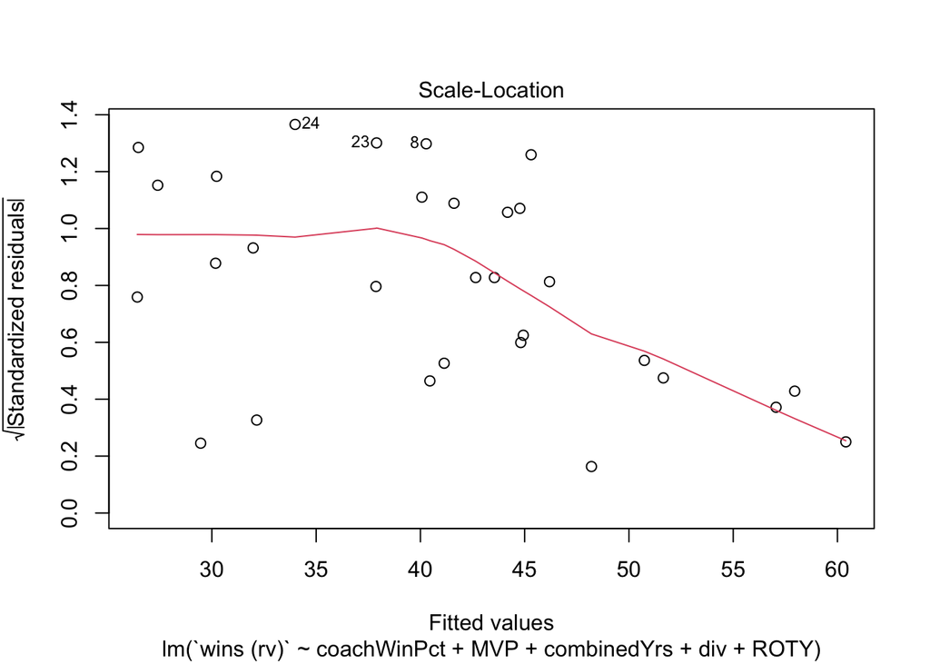

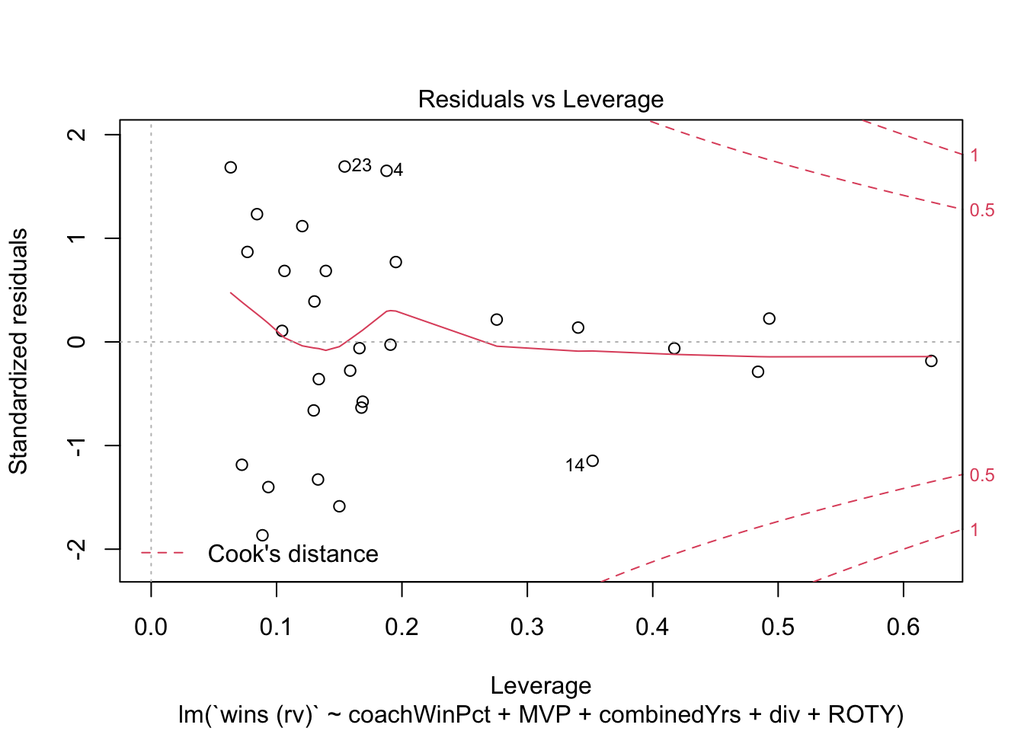

```r
plot(m1)
```

```r
summary(m1)
```

```
##
## Call:
## lm(formula = `wins (rv)` ~ coachWinPct + MVP + combinedYrs +
##     div + ROTY, data = basketballdata)
##
## Residuals:
##      Min       1Q   Median       3Q      Max
## -14.9910  -4.7574  -0.3021   5.4255  13.7227
##
## Coefficients:
##             Estimate Std. Error t value Pr(>|t|)
## (Intercept) -0.45543    8.77663  -0.052  0.95904
## coachWinPct  0.55470    0.15974   3.473  0.00197 **
## MVP          3.22367    6.04811   0.533  0.59893
## combinedYrs  0.10617    0.06901   1.538  0.13703
## div          0.50184    0.26533   1.891  0.07070 .
## ROTY         5.69019    3.36056   1.693  0.10336
## ---
## Signif. codes:  0 '***' 0.001 '**' 0.01 '*' 0.05 '.' 0.1 ' ' 1
##
## Residual standard error: 8.417 on 24 degrees of freedom
## Multiple R-squared:  0.5948, Adjusted R-squared:  0.5104
## F-statistic: 7.045 on 5 and 24 DF,  p-value: 0.0003523
```

#Conclusion: Our project attempted to find variables to predict NBA regular season wins and incorporate these variables into a model. Based on our model we can conclude that the variables that fit best into a model are coachWinPct, MVP, combinedYrs, div, and ROTY. This model is useful for providing some insight on how much the variables can affect a teams number of wins in a season; however, this should not be a primary indicator for how many wins a team gets. Other on the court and qualitative factors can have larger impacts such as player fits, injuries, and player relationships. To improve this aspect of the model, we could attempt to quantify many of these concepts and encode them as variables and eliminate variables from the top; however, this would be most beneficial with insider analysis from those closest to the league as much of this information could be subjective. This notion corresponds mainly to our variables but also to our model. Ultimately, this model gives us an idea of how much each variables corresponds to wins in comparison to each other.